**Chapter 1: Wildlife population ecology at the interface of humans and biodiversity**

[figure not shown]

## Overwiew

COVID-19 took a toll on humans, killing nearly 2 million people in 2020 alone. Of course, all humans were not equally exposed to death by Covid, with substantial variation explained by within-country responses, age, racial groups, and socio-economic status. In this exercise, we explore COVID-19 data, made available by [Our World in Data](https://ourworldindata.org/coronavirus). This dataset contains information provided by several sources including the United Nations, World Bank, World Health Organization, etc. Please check the meta data [here](https://github.com/owid/covid-19-data/blob/master/public/data/owid-covid-codebook.csv).

## Filtering data

In this dataset, there are multiple rows for each country. The original file contains detailed information about the daily progression in the number of cases, deaths and other information. First, we filter the data set and extract the information in which we are interested. For simplicity, we remove rows with missing data/NA.

```r
library(utils)

data <- read.csv("https://covid.ourworldindata.org/data/owid-covid-data.csv",
                 na.strings = "",
                 fileEncoding = "UTF-8-BOM")

covid_data <- data[, c("continent",
                        "location",
                        "hospital_beds_per_thousand",
                        "life_expectancy",
                        "total_cases",
                        "total_deaths",
                        "aged_65_older",
                        "aged_70_older",
                        "gdp_per_capita"
                       )]

clean_data <- na.omit(covid_data)
```

We make sure both continent and location are factor variables, with levels referring to actual values still in the filtered data. In addition, we calculate the average values of the number of hospital beds per 1000 inhabitants and life expectancy for each country.

```r
clean_data$continent <- factor(clean_data$continent)
clean_data$location  <- factor(clean_data$location)
avg_data   <- aggregate(. ~ location + continent,
                         data = clean_data,
                         FUN = mean,
                         drop = FALSE,
                         na.rm = TRUE)
```

Finally, in anticipation of plots that compare countries in terms of the number of hospital beds per 1000 inhabitants and share of the population that is 65 and older, we sort the rows in the table according to the number of hospital beds, in descending order.

```r
avg_data <- avg_data[order(avg_data$hospital_beds_per_thousand, decreasing = TRUE),]
```

## Visualizing data

Let’s start by looking at the distribution of life expectancy across countries. We can use function hist() to plot a histogram.

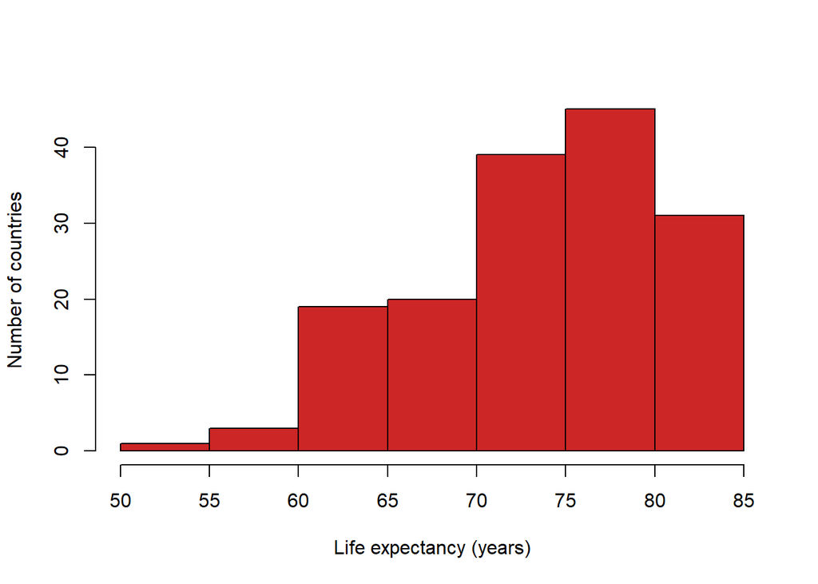

```r
hist(avg_data$life_expectancy,
     xlab = "Life expectancy (years)",
     ylab = "Number of countries",
     col  = "firebrick3",
     main = "")
```

Life expectancy at birth has increased almost continuously across the world for the past couple of centuries. COVID-19 in 2020 decreased life expectancy by >1.5 years, erasing most gains in life expectancy from the previous 5 years. But COVID-19 has tended to cause fatalities disproportionately among older age groups (>64 and among males). The largest reductions in life expectancy driven by Covid during 2020 were in the United States, where life expectancy for males dropped by >2 years.

Let’s use a scatter plot to see whether there is an indication of a relationship between the average life expectancy and the number of hospital beds. We color code observations according to the continent. In addition, we mark and label the observation for the United States.

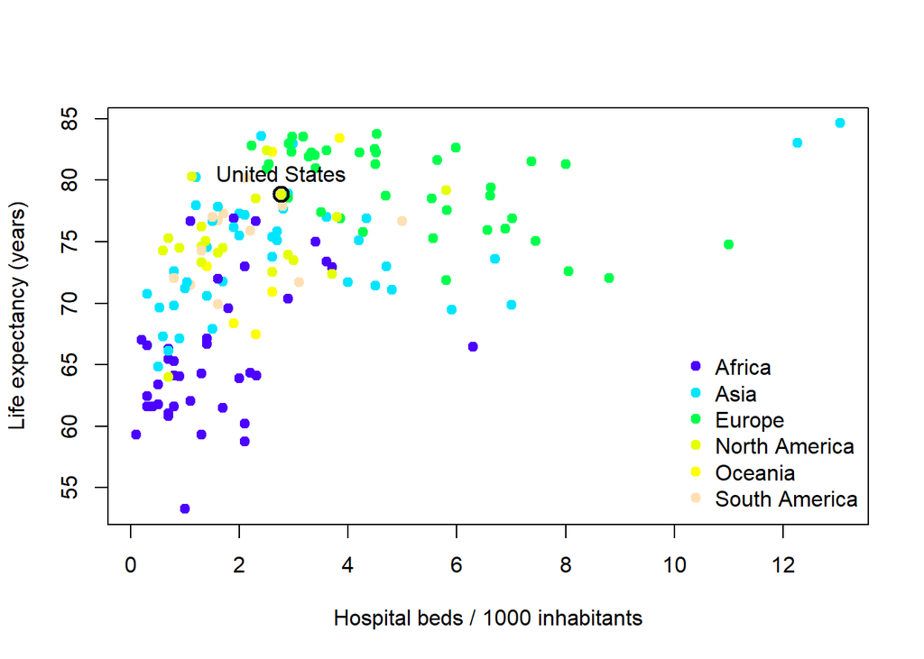

```r
continent_list <- levels(avg_data$continent)

colors <- topo.colors(length(continent_list))

names(colors) <- continent_list

plot(life_expectancy ~ hospital_beds_per_thousand,
     data = avg_data,
     pch = 19,
     col = colors[continent],
     xlab = "Hospital beds / 1000 inhabitants",
     ylab = "Life expectancy (years)")

legend("bottomright",
       legend = continent_list,
       pch = 19,
       col = colors,
       bty = "n")

points(life_expectancy ~ hospital_beds_per_thousand,
       data = avg_data[avg_data$location =="United States",],
       pch = 1,
       col = "black",
       cex = 1.5,
       lwd = 2)

text(avg_data[avg_data$location == "United States",
              "hospital_beds_per_thousand"],
     avg_data[avg_data$location == "United States",
              "life_expectancy"],
     "United States",
     pos = 3)
```

The previous plot suggests some pronounced differences between continents both in terms of the average number of hospital beds and average life expectancy. We can visualize these comparisons using box plots.

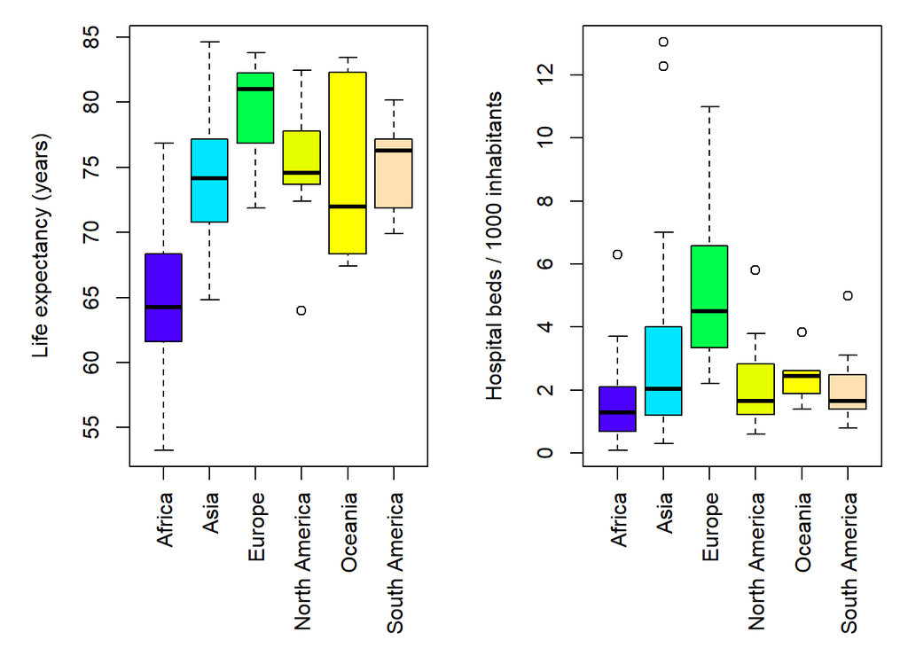

```r
par(mfrow = c(1, 2), mar = c(7, 5, 1, 1), las = 3)

boxplot(life_expectancy ~ continent,
        data = avg_data,
        col  = colors,
        ylab = "Life expectancy (years)",
        xlab = NA)

boxplot(hospital_beds_per_thousand ~ continent,
        data = avg_data,
        col  = colors,
        ylab = "Hospital beds / 1000 inhabitants",
        xlab = NA)
```

Now we can make a comparison between counties in terms of the number of hospital beds per 1000 inhabitants. First let’s reduce the data to only the first 20 records (the 20 countries with the most hospital beds per inhabitant). Then we use function barplot() to display the results.

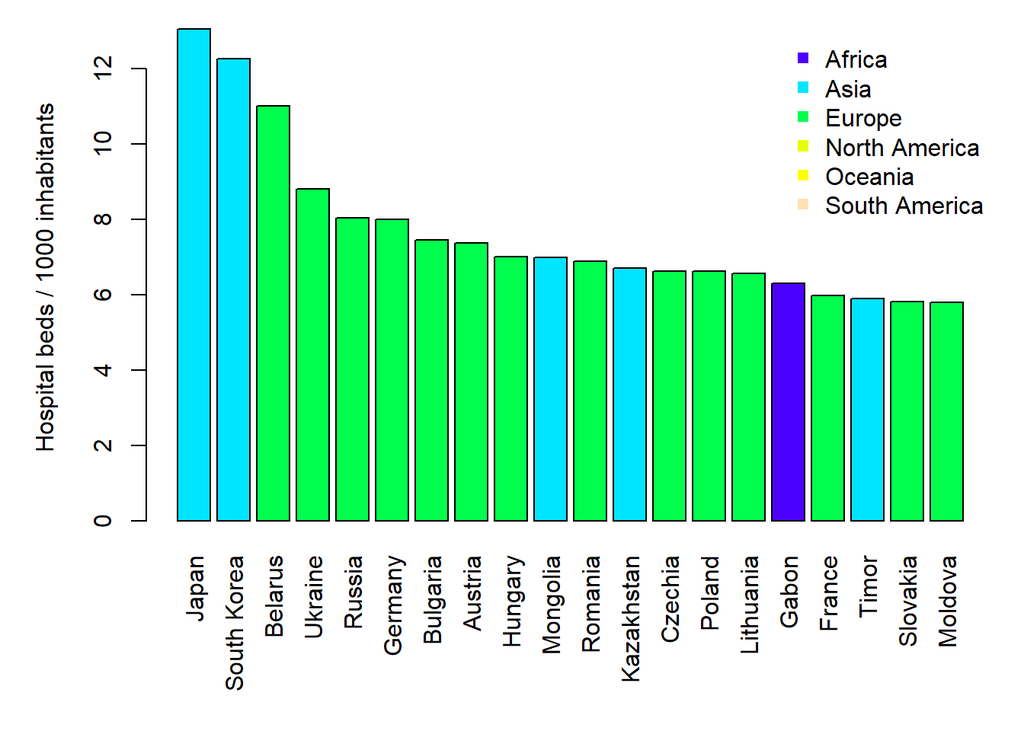

```r
bar_data <- avg_data[1:20,]

par(mfrow = c(1, 1), mar = c(7, 5, 1, 1), las = 3)

barplot(bar_data$hospital_beds_per_thousand,
        names.arg =  bar_data$location,
        col = colors[bar_data$continent],
        ylab = "Hospital beds / 1000 inhabitants")

legend("topright", legend = continent_list, col = colors, bty = "n", pch = 15 )
```

**Practice:**

Use plots to explore the data: 1) Make a comparison between continents in terms of number of total covid deaths and share of the population that is 65 years and older. 2) Visualize the relationship between the total number of covid deaths and share of the population that is 70 years and older. Can you find the country with the most number of total Covid deaths? what is the share of its population that is 70 years and older?

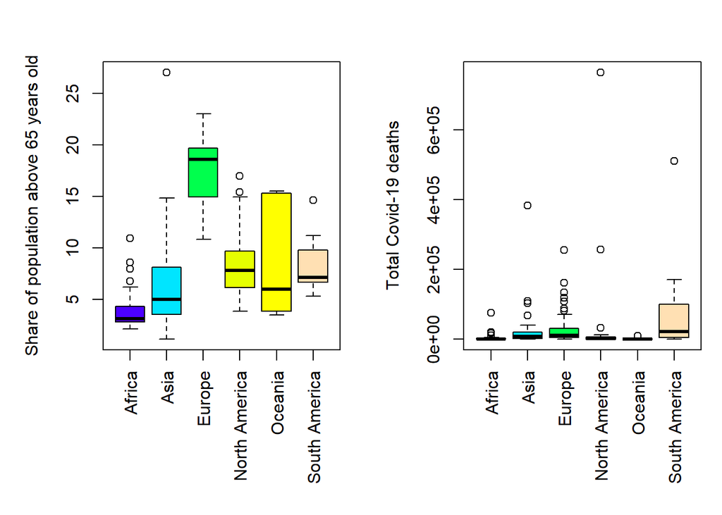

```r
par(mfrow = c(1,2), mar = c(8,5,3,1), las = 3)

boxplot(aged_65_older ~ continent,
        data = avg_data,
        col  = colors,
        ylab = "Share of population above 65 years old",
        xlab = NA)

boxplot(total_deaths ~ continent,
        data = avg_data,
        col  = colors,
        ylab = "Total Covid-19 deaths",
        xlab = NA)
```

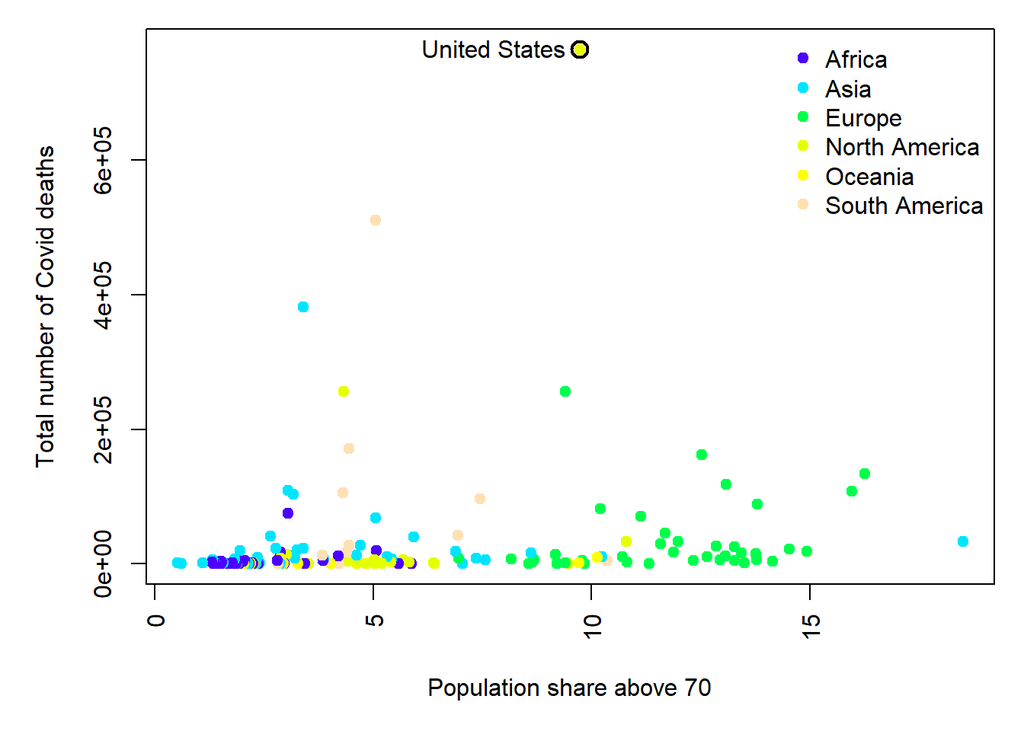

```r
par(mfrow = c(1,1), mar = c(5, 5, 1, 1), las = 3)

avg_data   <- aggregate(. ~ location + continent,
                         data = clean_data,
                         FUN = mean,
                         drop = FALSE,
                         na.rm = TRUE)
avg_data <- avg_data[order(avg_data$aged_70_older,
                           decreasing = TRUE),]

continent_list <- levels(avg_data$continent)

colors <- topo.colors(length(continent_list))

names(colors) <- continent_list
plot(total_deaths ~ aged_70_older,
     data = avg_data,
     pch  = 19,
     col  = colors[continent],
     xlab = "Population share above 70",
     ylab = "Total number of Covid deaths")

legend("topright",
       legend = continent_list,
       pch = 19,
       col = colors,
       bty = "n")

points(total_deaths ~ aged_70_older,
       data = avg_data[avg_data$location =="United States",],
       pch = 1,
       col = "black",
       cex = 1.5,
       lwd = 2)

text(avg_data[avg_data$location == "United States",
              "aged_70_older"],
     avg_data[avg_data$location == "United States",
              "total_deaths"],
     "United States",
     pos = 2)
```